# Introduction to single-cell RNA-seq analysis - Differential expression and abundance between conditions

November 2021

## Outline

- Motivation
- Differential expression
- Differential abundance

## Single Cell RNAseq Analysis Workflow

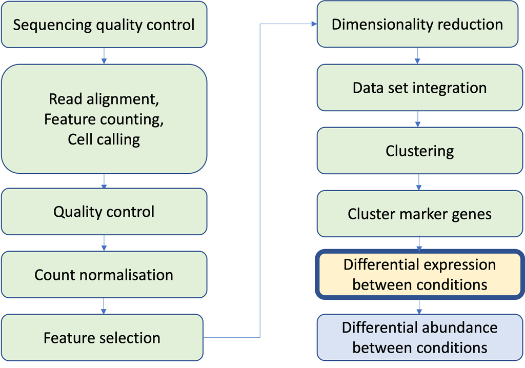

## Motivation

Clusters and/or cell types have been identified, we now want to compare sample groups:

- which genes vary in expression ?
- which clusters differ in abundance ?

Replicates are samples not cells:

- single cells within a sample are not independent of each other,
- using cells as replicates amounts to studying variation among an individual
- while we want to study variation across a population

Pseudo-bulk:

- gene expression levels for each cluster in each sample
- are obtained by summing across cells

## Differential expression between conditions

An example. TSNE plots showing clusters and sample groups (left) and samples (right):

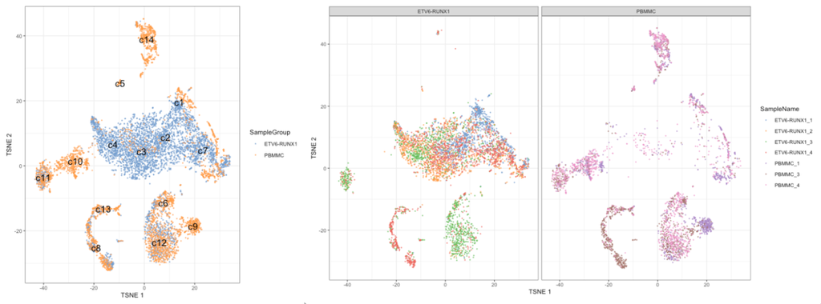

## Differential expression between conditions

Workflow:

- compute pseudo-bulk count by summing across cells,
  - per cluster and per sample
- perform bulk analysis with few replicates,
  - for each cluster separately

Method:

- quasi-likelihood (QL) methods from the `edgeR` package
- negative binomial generalized linear model (NB GLM)
  - to handle overdispersed count data
  - in experiments with limited replication

## Differential expression between conditions

Steps:

- Remove samples with very low library sizes, e.g. < 20 cells
  - better normalisation
- Remove genes that are lowly expressed,
  - reduces computational work,
  - improves the accuracy of mean-variance trend modelling
  - decreases the severity of the multiple testing correction
  - filter: log-CPM threshold in a minimum number of samples, smallest sample group
- Correct for composition biases
  - by computing normalization factors with the trimmed mean of M-values method
- Test whether the log-fold change between sample groups is significantly different from zero
  - estimate the negative binomial (NB) dispersions
  - estimate the quasi-likelihood dispersions, uncertainty and variability of the per-gene variance

## Single Cell RNAseq Analysis Workflow

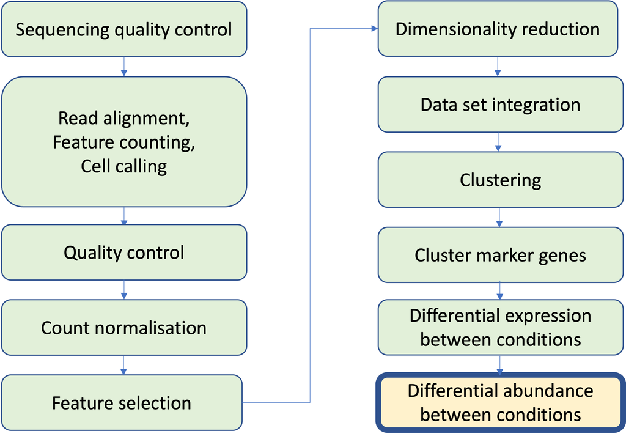

## Differential abundance between conditions

Aim:

- test for significant changes in per-cluster cell abundance across conditions

Example:

- which cell types are depleted or enriched upon treatment?

Steps:

- Count cells assigned to each label, i.e. cluster or cell type
- Same workflow as for differential expression above,
  - except counts are of cells per label, not of reads per gene
- Share information across labels
  - to improve our estimates of the biological variability in cell abundance between replicates.